# Single-cell RNA seq pipeline - Rimensionality reduction

Stefan Filges

2020-06-12

```r
#----------------------- // USER defined variables //---------------------------
# define the working directory
working_directory <- "~/GitHub/SingleCellScripts/"

# run sctransform, this replaces the NormalizeData, ScaleData and FindVariableFeatures
sctransform = FALSE

# Should cell cycle filtering be applied or not?
filter_cell_cycle = FALSE
#--------------------------------------------------------------------------------------

# set other directories based on working directory
figures_dir <- paste(working_directory,"figures/",sep="")
rdata_dir <- paste(working_directory,"data/Rdata/",sep="")

# define output file to save Seurat object for re-use
seurat_object_final <- paste(rdata_dir,"seurat_object_final.Rdata",sep="")

# load preprocessed object
seurat_object_save <- paste(rdata_dir,"seurat_object_preprocessed.Rdata",sep="")
load(seurat_object_save)

# Packages for main analysis, clustering, data structures etc.
suppressMessages(library(Seurat, quietly = TRUE))
suppressMessages(library(SummarizedExperiment, quietly = TRUE))
suppressMessages(library(sctransform, quietly = TRUE))
suppressMessages(library(tidyverse, quietly = TRUE))
suppressMessages(library(viridis, quietly = TRUE))
suppressMessages(library(RColorBrewer, quietly = TRUE))
```

## Identification of highly variable features (feature selection)

Even after removing features found in only a few cells and removing artefacts the data set may be very large with > 15,000 features. Thus, only genes highly variable across the data set are used for downstream analysis. According to Luecken and Theis typical cut-offs are between 1000 and 5000 genes. Although downstream analysis is robust as to the the number of genes chosen, they recommend to use larger values. We used 2000 genes, the default in the Seurat package.

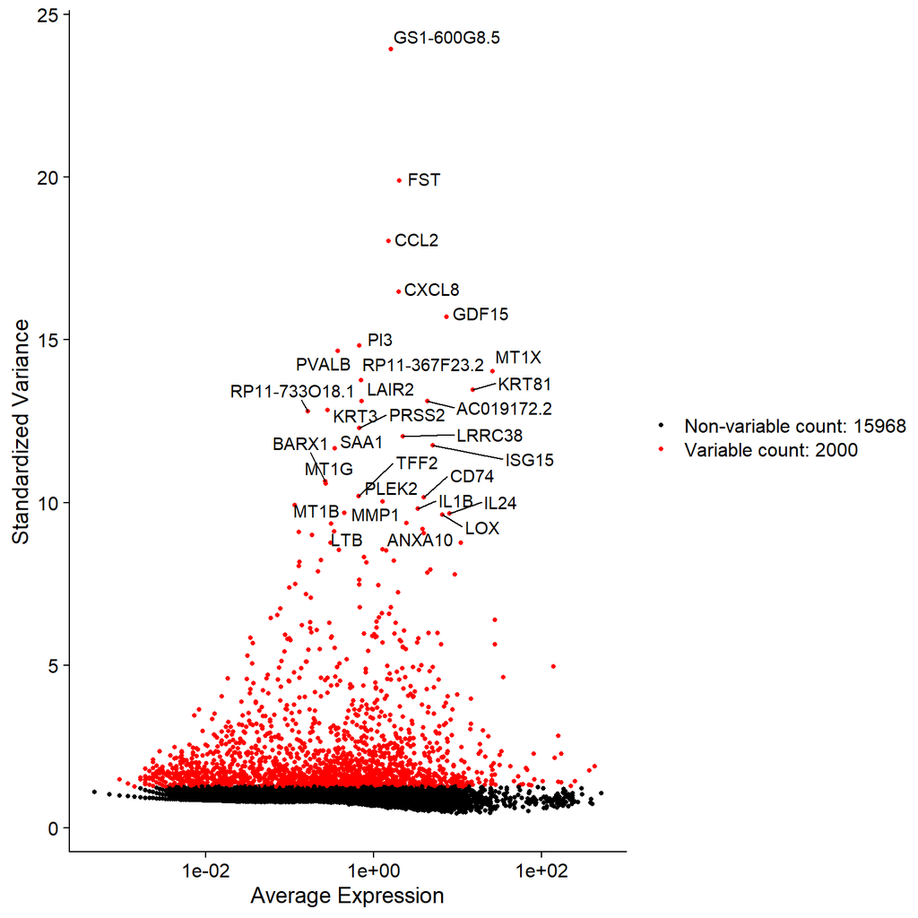

```r
# Identify the 10 most highly variable genes
top30 <- head(x = Seurat::VariableFeatures(object = merged_data), 30)

# plot variable features with and without labels
plot1 <- Seurat::VariableFeaturePlot(object = merged_data)
Seurat::LabelPoints(plot = plot1, points = top30, repel = TRUE)
```

## Dimensionality reduction & clustering

Despite containing many cells and features scRNA-seq data is inherently low-dimensional, i.e. most biological variation in scRNA-seq data can be shown in few dimensions.

Dimensionality reduction techniques generate reduced representations through linear or non-linear combination of gene expression vectors. Non-linear methods like [tSNE](http://www.jmlr.org/papers/v9/vandermaaten08a.html) and [UMAP](https://www.nature.com/articles/nbt.4314) result in better cell visualisations because they capture local similaity in high-dimensional data better than linear methods such as PCA. However, non-linear reduced dimensions are not straight-forward to interpret, wheras principal components and their associated gene loadings can be interpreted easily.

Dimensionality reduction techniques should be interpreted separatly: PCA or diffusion maps for general purpose summarization and trajectory inference, UMAP for exploratory visualization and UMAP with PAGA for complex data sets.

### Principal component analysis

We first apply PCA to the merged data set and print the top five features (loadings) for each of the first five principal components, both in positive and negative direction.

We visualise the PCA in two dimensions and colour cells by sample ID. The elbow plot showws the PCs ranked by variance contribution, allowing us to determine a reduced dimensionality for downstream processing. Typically we want to choose the number of PC around a “hinge” in the elbow plot. Alternatively a statistical procedure called Jackstraw, implemented in Seurat, can be used to determine the significance of PCs using resampling.

We also plot the top positive and negative loadings for the first six dimensions in a heatmap.

```r
merged_data <- Seurat::RunPCA(
  object = merged_data,
  verbose = FALSE
)

elbow_plot <- Seurat::ElbowPlot(
  object = merged_data
)

print(x = merged_data[['pca']], dims = 1:5, nfeatures = 5)
```

```
## PC_ 1
## Positive:  H2AFZ, HMGB1, HMGB2, STMN1, KIAA0101
## Negative:  FTL, CD44, NDRG1, ENO2, CYSTM1
## PC_ 2
## Positive:  IL24, PDLIM1, CCT5, GSTP1, FILIP1
## Negative:  C4orf3, MME, LOX, FN1, PLOD2
## PC_ 3
## Positive:  LSP1, TSC22D1, ATF3, C11orf31, ARID5B
## Negative:  PGK1, ENO1, CA9, ALDOA, LDHA
## PC_ 4
## Positive:  AC019172.2, MT1X, CKS2, RBCK1, FGF10-AS1
## Negative:  ANXA2, RPN2, SERPINE2, HSP90B1, SPARC
## PC_ 5
## Positive:  SPARC, PAEP, TSC22D1, HTRA1, ADA
## Negative:  MT2A, RPS3, MT1E, ODC1, C19orf33
```

```r
merged_data <- Seurat::JackStraw(
  object = merged_data,
  num.replicate = 100
)
```

```r
merged_data <- Seurat::ScoreJackStraw(
  object = merged_data,
  dims = 1:15
)

jackstraw_plot <- Seurat::JackStrawPlot(
  object = merged_data,
  dims = 1:15
)

pca_dim_plot <- Seurat::DimPlot(
  object = merged_data,
  reduction = 'pca',
  group.by = 'group'
)

pca_dim_loadings <- Seurat::VizDimLoadings(
  object = merged_data,
  dims = 1:2,
  reduction = 'pca',
  combine = TRUE
)

pca_dim_heatmap <- Seurat::DimHeatmap(
  object = merged_data,
  dims = 1:6,
  cells = 500,
  balanced = TRUE,
  fast = FALSE
)
```

#### PCA

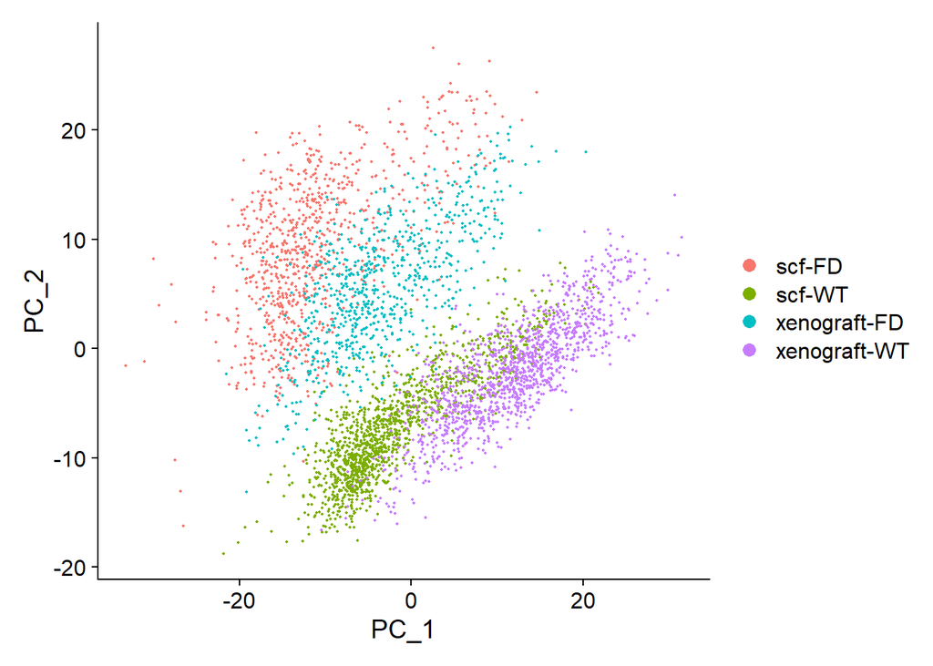

#### Loadings

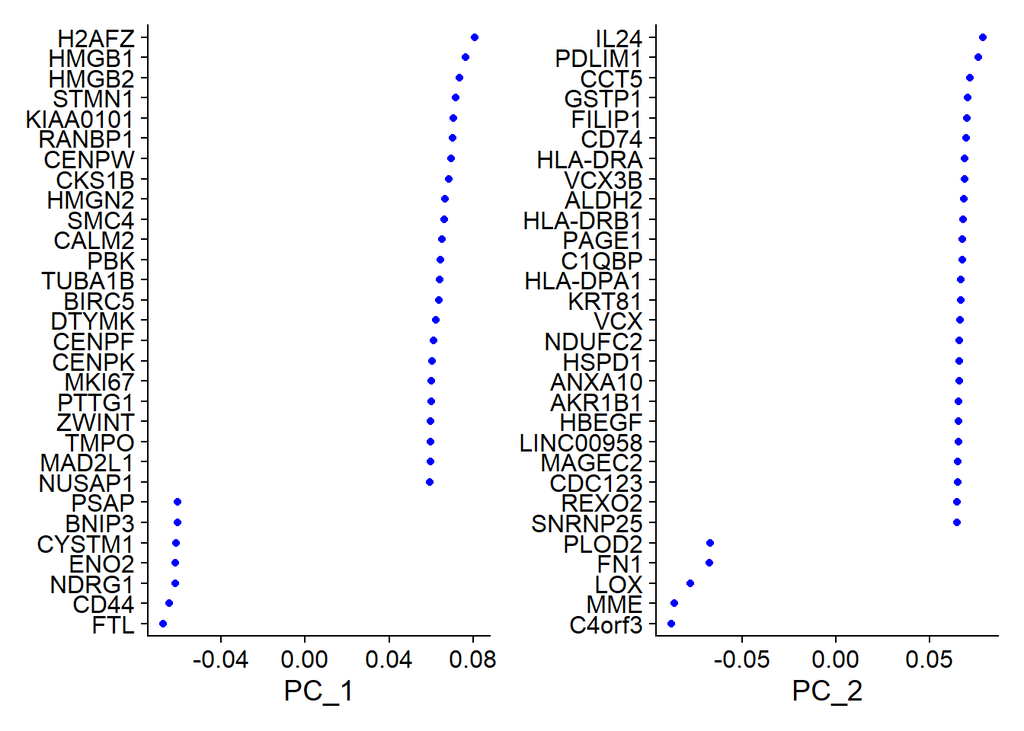

#### Heatmap

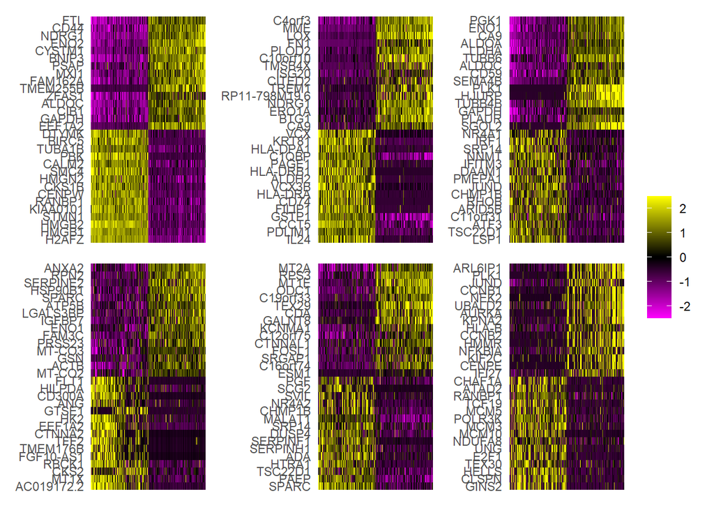

#### Jackstraw

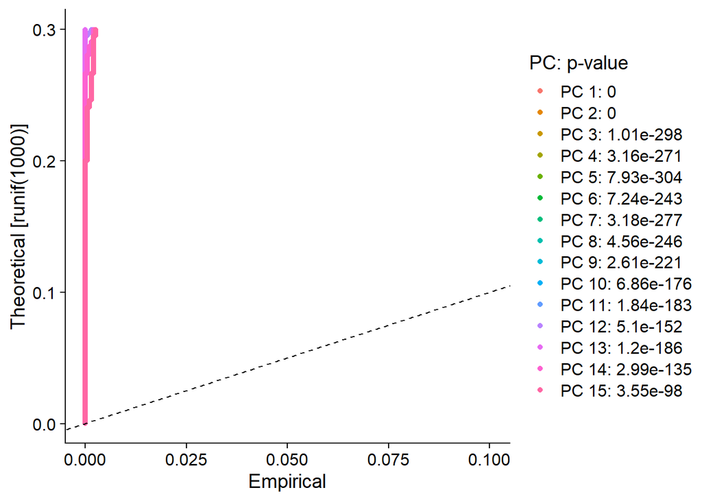

#### Elbow

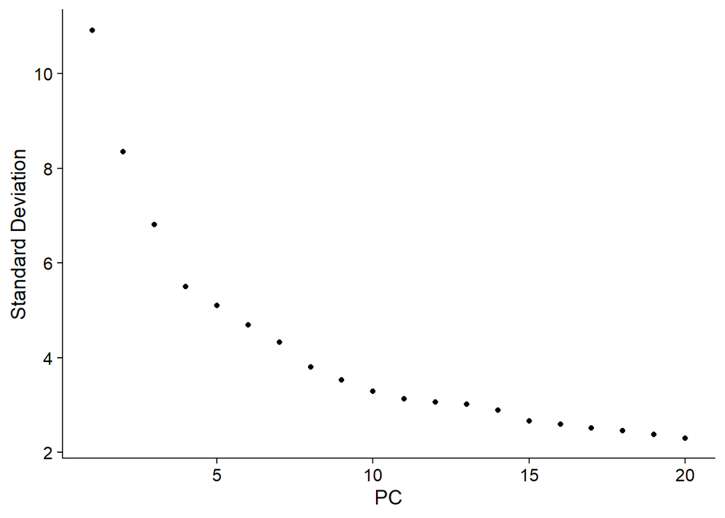

### Neighbour embedding and clustering

As in PhenoGraph, we first construct a k-nearest neighbour (KNN) graph based on the euclidean distance in PCA space, and refine the edge weights between any two cells based on the shared overlap in their local neighborhoods (Jaccard similarity). This step is performed using the FindNeighbors function, and takes as input the previously defined dimensionality of the dataset (first 15 PCs).

To cluster the cells, we next apply modularity optimization techniques such as the Louvain or Leiden algorithms, to iteratively group cells together, with the goal of optimizing the standard modularity function. The FindClusters function implements this procedure, and contains a resolution parameter that sets the ‘granularity’ of the downstream clustering, with increased values leading to a greater number of clusters. We find that setting this parameter between 0.4-1.2 typically returns good results for single-cell datasets of around 3K cells. Optimal resolution often increases for larger datasets. The clusters can be found using the Idents function. A relatively easy explanation of the Louvain and Leiden algorithms is bublished [here](https://www.nature.com/articles/s41598-019-41695-z).

```r
# Constructs a Shared Nearest Neighbor (SNN) Graph for a given dataset. We first
# determine the k-nearest neighbors of each cell. We use this knn graph to construct the
# SNN graph by calculating the neighborhood overlap (Jaccard index) between every cell
# and its k.param nearest neighbors.
merged_data <- Seurat::FindNeighbors(
  object = merged_data,
  k.param = 20,
  dims = 1:15
)

# Find clusters by optimizing modularity of a shared nearest neigbour graph using
# community detection
# algorithm = 2 (Louvain)
# algorithm = 4 (Leiden)
# default resolution is 0.8; use a value above (below) 1.0 if you want to obtain a larger (smaller) number of communities
merged_data <- Seurat::FindClusters(
  object = merged_data,
  algorithm = 2,
  resolution = 1.2
)
```

```
## Modularity Optimizer version 1.3.0 by Ludo Waltman and Nees Jan van Eck
##
## Number of nodes: 4192
## Number of edges: 144085
##
## Running Louvain algorithm with multilevel refinement...
## Maximum modularity in 10 random starts: 0.8094
## Number of communities: 17
## Elapsed time: 0 seconds
```

```r
merged_data <- Seurat::RunUMAP(
  object = merged_data,
  dims = 1:15
)
```

### Visualising low-dimensional representations

#### Samples

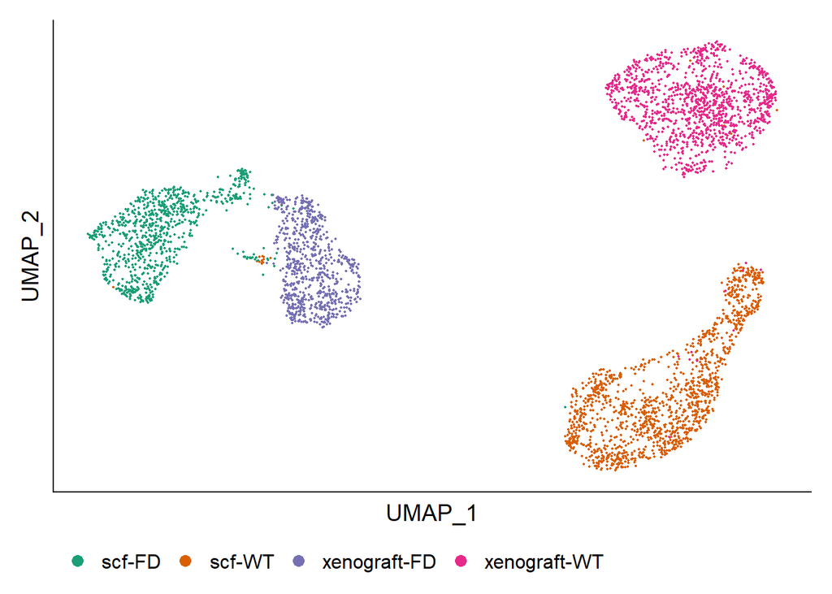

#### Clusters

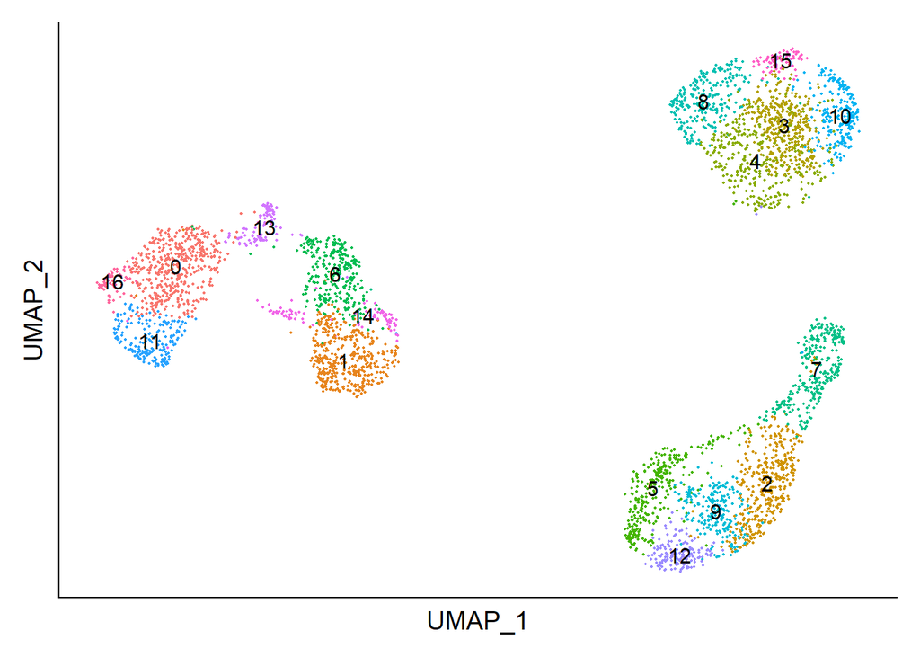

#### Cell cycle

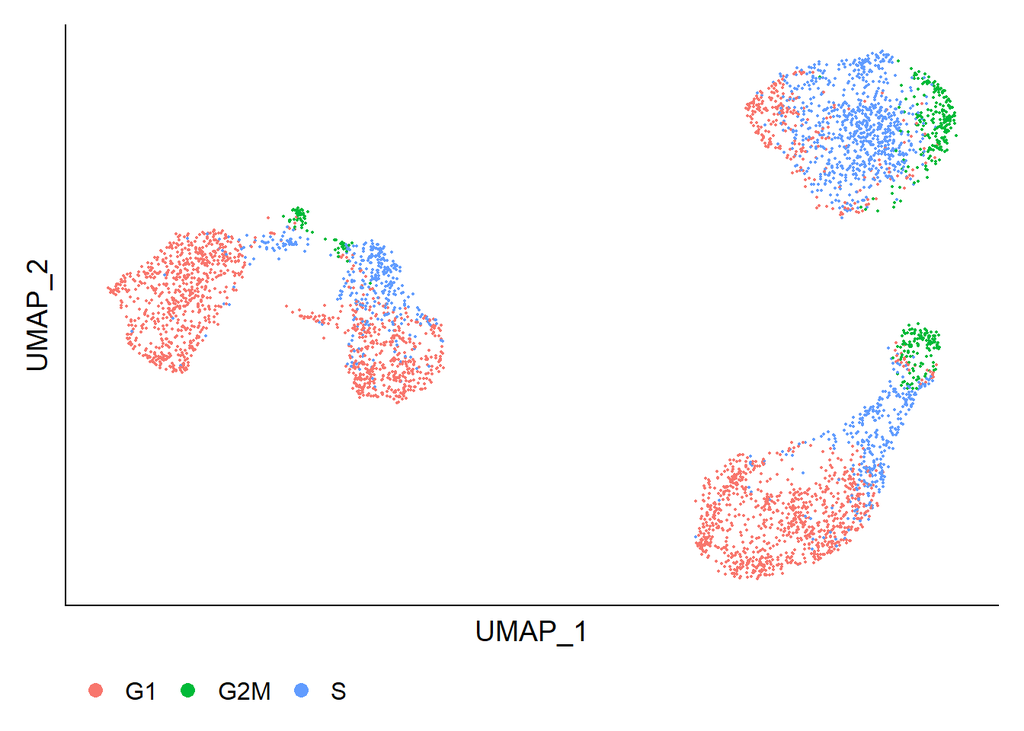

#### Combined

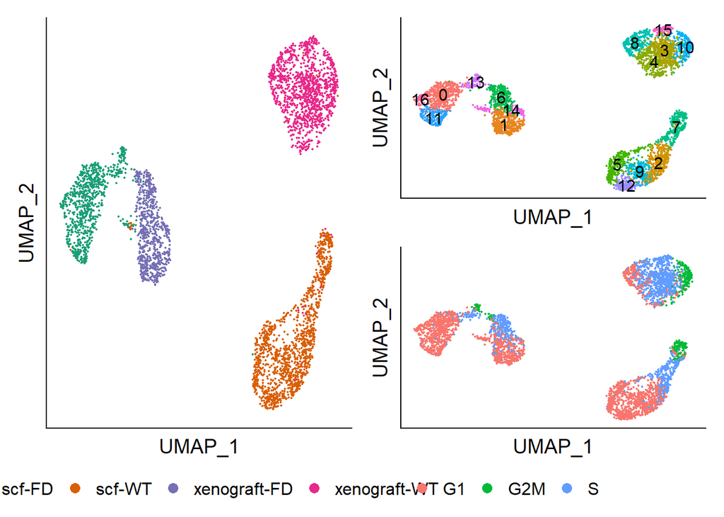